# Statistics Review

Our dataset often is presented as a matrix, where each row is a different gene and each column is a different experiment.

Letâs create a random set of values for 20,000 genes and 12 experiments.

- **sample()** function can be useful in generating random numbers give a range.
- this gives us a *unif* distribution

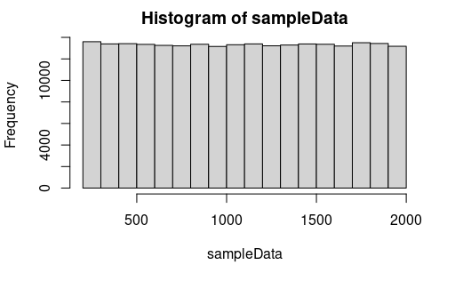

But if we want data to be from normal distribution we should use **rnorm**.

[figure not shown]

```r
expvalues = matrix(randomData, ncol=12, nrow=20000)
```

Letâs suppose the first 6 values are from a *wildtype* *c.elegans* and the last 6 are from *mutant*.

For each genes, what statistical method can I use to determine if the gene is differentially expressed. DE means - means of a gene in the two conditions are significantly different.

- we can use either t-test or ANOVA.

```r
genotype = as.factor(rep(c("w","m"), each=6))
genotype
```

```
 [1] w w w w w w m m m m m m
Levels: m w
```

```r
aovsum = summary(aov(expvalues[1,] ~ genotype))

# to get the p-value for each anova result use command below
aovsum[[1]]$`Pr(>F)`[1]
```

```
[1] 0.02719791
```

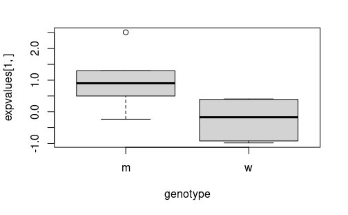

```r
boxplot(expvalues[1,] ~ genotype)
```

```r
pvalues = numeric()
for (i in 1:nrow(expvalues)) {

  aovsum_temp = summary(aov(expvalues[i,] ~ genotype))

# to get the p-value for each anova result use command below
  pvalues[i] = aovsum_temp[[1]]$`Pr(>F)`[1]
}
```

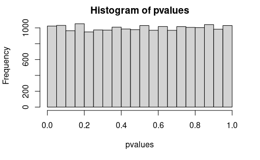

```r
hist(pvalues)
```

```r
sum(sig_gene_logic)
```

```
[1] 1023
```

need to correct for multiple hypothesis testing using FDR as cutoff and not just p-value.

```r
p_adj = p.adjust(pvalues, method="FDR")
```

```
Error in match.arg(method) :
  'arg' should be one of âholmâ, âhochbergâ, âhommelâ, âbonferroniâ, âBHâ, âBYâ, âfdrâ, ânoneâ
```

```r
sum(p_adj < 0.05)
```

```
[1] 0
```

Alternativaly we can adjust for the FWER using Bonferroni

```r
sum(b_adj < 0.05)
```

```
[1] 0
```

To do a 2-factor ANOVA, we need two factors. Letâs assume that the 1-3, 7-9 are **control** and 4-6, 10-12 are **treatment**

```r
treatment = factor(rep(rep(c('c','t'), each=3),2))
treatment
```

```
 [1] c c c t t t c c c t t t
Levels: c t
```

```r
aovsum
```

[output not shown]

[figure not shown]

```r
# to get the p-value for each anova result use command below
length(aovsum[[1]]$`Pr(>F)`[1:3])
```

```
[1] 3
```

```r
interactionpvalues = matrix(NA,nrow=nrow(expvalues),ncol=3)

for (i in 1:nrow(expvalues)) {

  aovsum_temp = summary(aov(expvalues[i,] ~ genotype * treatment))
  #print(aovsum_temp)
# to get the p-value for each anova result use command below
  interactionpvalues[i,] = aovsum_temp[[1]]$`Pr(>F)`[1:3]
}
```